# **Yates Lab** - Statistical Modeling of Visual Neural Encoding

## Visualize the Weights

A nice detail of simple models like this GLM is that the weights can be interpreted visually. The visualization provides a general idea of the spatio-temporal selectivity of the system you are modeling.

Hint: axis 0 of your reshaped weights should represent the unit ("neuron") index.

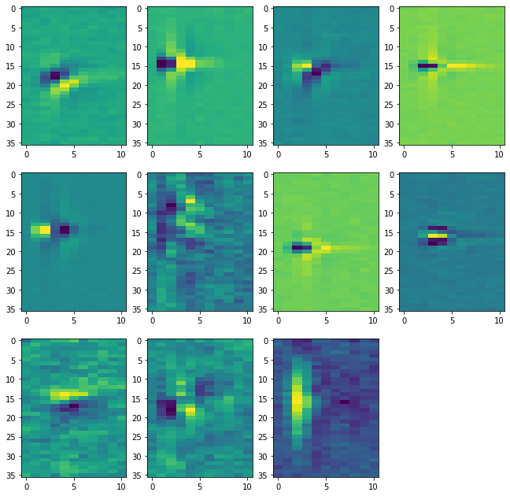

```python
weights =         model[0].weight# TODO: get the weights from your model.
shaped_weights =  weights.reshape(NC, 36, num_lags)# TODO: reshape the weights to 3D so they can be displayed

# Convert to numpy array for plotting
np_weights = shaped_weights.detach().cpu().numpy()

# Plot
plt.figure(figsize=(11, 11))
for cc in range(11):
  plt.subplot(3, 4, cc+1)
  unit = np_weights[cc, :, :]# TODO select a slice from the unit ("neuron") number cc to plot.
  plt.imshow(unit, aspect='auto', interpolation='none')
```

## Visualize the Model's Predicitons

Regardless of the complexity of the model, we can visualize its predicitions and compare it to the ground truth.

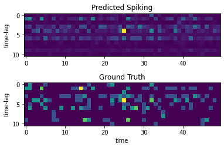

```python
num_samples = 50
vis_test_dataloader = torch.utils.data.DataLoader(test_dataset, batch_size=num_samples)
vis_data = next(iter(vis_test_dataloader))
vis_data_input = vis_data['stim']
vis_data_output = vis_data['robs']

pred = None
with torch.no_grad():
  pred = model(vis_data_input)

# Plot
pred = pred.detach().cpu().numpy().T
out = vis_data_output.detach().cpu().numpy().T
plt.figure()
plt.subplot(2, 1, 1)
plt.imshow((pred - pred.mean()) / pred.std(), interpolation='none')
plt.gca().set_title("Predicted Spiking")
plt.ylabel("time-lag")
plt.subplot(2,1,2)
plt.imshow((out - out.mean()) / out.std(), interpolation='none')
plt.gca().set_title("Ground Truth")
plt.ylabel("time-lag")
plt.xlabel("time")
```

## Customizing the Model

Up to this point we used native PyTorch tools. However, we can improve upon the performance by utilizing specialized modules. These modules have useful functions such as localized weight regularization, null-adjusted log likelihood, and automatic weight reshaping.

In addition, they include implementations for useful optimizers such as LBFGS which is a second order method that converges much more quickly than iterative methods (gradient descent) for simple models.

Please Read the following alternative implementation of the model you built in Task 1. Feel free to explore the implementations for the imported tools from the local NDNT module.

```python
class GLM(nn.Module):

    def __init__(self,
                 intput_dims,
                 NC,
                 reg_vals = None):

        super().__init__()

        self.dims = intput_dims
        self.cids = np.arange(NC)
        self.loss = PoissonLoss_datafilter()

        # build model
        self.layer = NDNLayer(input_dims=self.dims,
                              num_filters=NC, reg_vals=reg_vals, bias=True,
                              NLtype='softplus')

    def forward(self, input):

        y = self.layer(input['stim'])

        return y

    def prepare_regularization(self, normalize_reg=False):

        self.layer.reg.normalize = normalize_reg
        self.layer.reg.build_reg_modules()

    def compute_reg_loss(self):

        return self.layer.compute_reg_loss()

    def training_step(self, batch, batch_idx=None):  # batch_indx not used, right?

        y = batch['robs']
        dfs = batch['dfs']

        y_hat = self(batch)

        loss = self.loss(y_hat, y, dfs)

        regularizers = self.compute_reg_loss()

        return {'loss': loss + regularizers, 'train_loss': loss, 'reg_loss': regularizers}

    def validation_step(self, batch, batch_idx=None):

        y = batch['robs']
        dfs = batch['dfs']

        y_hat = self(batch)

        loss = self.loss(y_hat, y, dfs)

        return {'loss': loss, 'val_loss': loss, 'reg_loss': None}
```

## Use Custom Training and Testing Tools From the NDNT Module

```python
# Custom GLM with weight regularization that enforces smoothness.
glm_model = GLM(dims, NC, reg_vals={'localx': 10, 'd2t':10})
glm_model.prepare_regularization()
glm_model.to(device)

# Use a custom second order optimizer for fast convergence
optimizer_lbfgs = torch.optim.LBFGS(glm_model.parameters(),
                          history_size=10,
                          max_iter=10e4,
                          tolerance_change=1e-9,
                          line_search_fn=None,
                          tolerance_grad=1e-5)

# Use a custom trainer.
trainer_glm = LBFGSTrainer(optimizer=optimizer_lbfgs,
                          device=device,
                          accumulate_grad_batches=len(train_dataloader),
                          max_epochs=1,
                          optimize_graph=True,
                          log_activations=False,
                          set_grad_to_none=False,
                          verbose=0)
```

```python
# Fit
trainer_glm.fit(glm_model, train_dataloader.dataset[:], val_dataloader.dataset[:])
```

**Visualize Weights**

What differences do you notice compared to the model you created in Task 1?

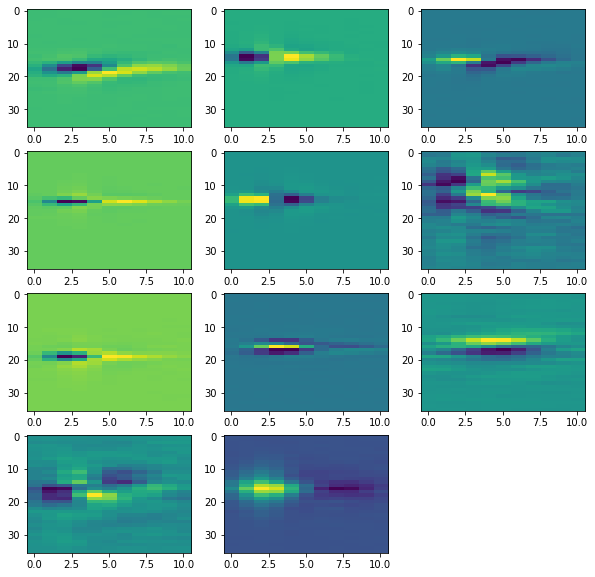

```python
# Visualizing the weights is so much easier with automatic reshaping!
ws = glm_model.layer.get_weights()

plt.figure(figsize=(10,10))
sx = int(np.ceil(np.sqrt(NC)))
sy = int(np.round(np.sqrt(NC)))

for cc in range(NC):
    plt.subplot(sx,sy,cc+1)
    plt.imshow(ws[:,:,cc], interpolation='none', aspect='auto')
```

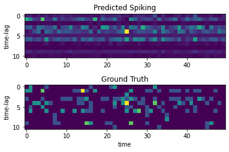

```python
num_samples = 50
vis_test_dataloader = torch.utils.data.DataLoader(test_dataset, batch_size=num_samples)
vis_data = next(iter(vis_test_dataloader))
vis_data_input = vis_data['stim']
vis_data_output = vis_data['robs']

pred = None
with torch.no_grad():
  glm_model.to(device)
  pred = glm_model(vis_data)

# Plot
pred = pred.detach().cpu().numpy().T
out = vis_data_output.detach().cpu().numpy().T
plt.figure()
plt.subplot(2, 1, 1)
plt.imshow((pred - pred.mean()) / pred.std(), interpolation='none')
plt.gca().set_title("Predicted Spiking")
plt.ylabel("time-lag")
plt.subplot(2,1,2)
plt.imshow((out - out.mean()) / out.std(), interpolation='none')
plt.gca().set_title("Ground Truth")
plt.ylabel("time-lag")
plt.xlabel("time")
```

**Evaluate Model Using Null-Adjusted LL**

We can use the following function for evaluating our model.

```python
def eval_model(model, valid_dl):
    loss = model.loss.unit_loss
    model.eval()

    LLsum, Tsum, Rsum = 0, 0, 0
    from tqdm import tqdm

    device = next(model.parameters()).device  # device the model is on
    if isinstance(valid_dl, dict):
        for dsub in valid_dl.keys():
                if valid_dl[dsub].device != device:
                    valid_dl[dsub] = valid_dl[dsub].to(device)
        rpred = model(valid_dl)
        LLsum = loss(rpred,
                    valid_dl['robs'][:,model.cids],
                    data_filters=valid_dl['dfs'][:,model.cids],
                    temporal_normalize=False)
        Tsum = valid_dl['dfs'][:,model.cids].sum(dim=0)
        Rsum = (valid_dl['dfs'][:,model.cids]*valid_dl['robs'][:,model.cids]).sum(dim=0)

    else:
        for data in tqdm(valid_dl, desc='Eval models'):

            for dsub in data.keys():
                if data[dsub].device != device:
                    data[dsub] = data[dsub].to(device)

            with torch.no_grad():
                rpred = model(data)
                LLsum += loss(rpred,
                        data['robs'][:,model.cids],
                        data_filters=data['dfs'][:,model.cids],
                        temporal_normalize=False)
                Tsum += data['dfs'][:,model.cids].sum(dim=0)
                Rsum += (data['dfs'][:,model.cids] * data['robs'][:,model.cids]).sum(dim=0)

    LLneuron = LLsum/Rsum.clamp(1)

    rbar = Rsum/Tsum.clamp(1)
    LLnulls = torch.log(rbar)-1
    LLneuron = -LLneuron - LLnulls

    LLneuron/=np.log(2)

    return LLneuron.detach().cpu().numpy()
```

```python
# Evaluate!
ll_glm = eval_model(glm_model, test_dataloader)
```

## Task 2

Using the tools from the GLM tutorial, build a new model that containes two linear layers and two activations (call it LNLN model).

Hints:

- First activation can be a RELU
- Second activation can be a softplus.
- The second layer has the same units as the GLM, but the first layer can have a flexible number of units.

```python
#TODO
class LNLN(nn.Module):

    def __init__(self, input_dims, num_subunits, NC, reg_vals = None):

        super().__init__()
        self.dims = input_dims
        self.num_subunits = num_subunits
        self.cids = np.arange(NC)
        self.loss = PoissonLoss_datafilter()

        # build model
        self.layer0 = NDNLayer(input_dims=self.dims,
                              num_filters=num_subunits, reg_vals=reg_vals, bias=True,
                              NLtype='relu')
        self.layer1 = NDNLayer(input_dims=[num_subunits, 1, 1, 1],
                              num_filters=NC, bias=True,
                              NLtype='softplus')

    def forward(self, input):

        y = self.layer0(input['stim'])
        return self.layer1(y)

    def prepare_regularization(self, normalize_reg=False):

        self.layer0.reg.normalize = normalize_reg
        self.layer1.reg.normalize = normalize_reg

        self.layer0.reg.build_reg_modules()
        self.layer1.reg.build_reg_modules()

    def compute_reg_loss(self):

        return self.layer0.compute_reg_loss() + self.layer1.compute_reg_loss()

    def training_step(self, batch, batch_idx=None):  # batch_indx not used, right?

        y = batch['robs']
        dfs = batch['dfs']

        y_hat = self(batch)

        loss = self.loss(y_hat, y, dfs)

        regularizers = self.compute_reg_loss()

        return {'loss': loss + regularizers, 'train_loss': loss, 'reg_loss': regularizers}

    def validation_step(self, batch, batch_idx=None):

        y = batch['robs']
        dfs = batch['dfs']

        y_hat = self(batch)

        loss = self.loss(y_hat, y, dfs)

        return {'loss': loss, 'val_loss': loss, 'reg_loss': None}
```

Train the model

```python
#TODO
num_subunits = 25
lnln_model = LNLN(dims, num_subunits, NC, reg_vals={'glocalx': 10, 'd2t': 10})
lnln_model.prepare_regularization()
lnln_model.to(device)

optimizer = torch.optim.LBFGS(lnln_model.parameters(),
                history_size=10,
                max_iter=10e4,
                tolerance_change=1e-9,
                line_search_fn=None,
                tolerance_grad=1e-5)

trainer = LBFGSTrainer(
    optimizer=optimizer,
    device=device,
    accumulate_grad_batches=len(train_dataloader),
    max_epochs=1,
    optimize_graph=True,
    log_activations=False,
    set_grad_to_none=False,
    verbose=0)

trainer.fit(lnln_model, train_dataloader.dataset[:], val_dataloader.dataset[:])
```

Evaluate it

```
(25, 11)
```

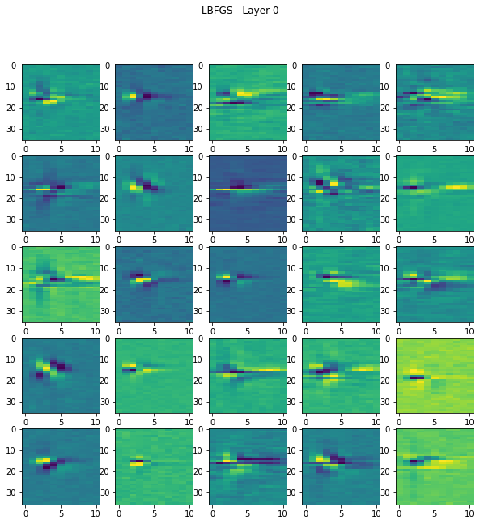

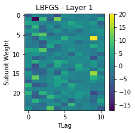

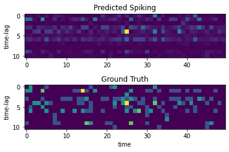

```python
#TODO

#Evaluate LL
ll_lnln = eval_model(lnln_model, test_dataloader)

#Visualize Weights
ws = lnln_model.layer0.get_weights()
plt.figure(figsize=(10,10))
plt.suptitle("LBFGS - Layer 0")
sx = int(np.ceil(np.sqrt(num_subunits)))
sy = int(np.round(np.sqrt(num_subunits)))

for cc in range(num_subunits):
    plt.subplot(sx,sy,cc+1)
    plt.imshow(ws[:,:,cc], interpolation='none', aspect='auto')

ws = lnln_model.layer1.get_weights()
print(ws.shape)
plt.figure(figsize=(3,3))
plt.title("LBFGS - Layer 1")
plt.xlabel("TLag")
plt.ylabel("Subunit Weight")
plt.imshow(ws, interpolation='none', aspect='auto')
plt.colorbar()

# Compare predictions to ground truth
num_samples = 50
vis_test_dataloader = torch.utils.data.DataLoader(test_dataset, batch_size=num_samples)
vis_data = next(iter(vis_test_dataloader))
vis_data_input = vis_data['stim']
vis_data_output = vis_data['robs']

pred = None
with torch.no_grad():
  lnln_model.to(device)
  pred = lnln_model(vis_data)

# Plot
pred = pred.detach().cpu().numpy().T
out = vis_data_output.detach().cpu().numpy().T
plt.figure()
plt.subplot(2, 1, 1)
plt.imshow((pred - pred.mean()) / pred.std(), interpolation='none')
plt.gca().set_title("Predicted Spiking")
plt.ylabel("time-lag")
plt.subplot(2,1,2)
plt.imshow((out - out.mean()) / out.std(), interpolation='none')
plt.gca().set_title("Ground Truth")
plt.ylabel("time-lag")
plt.xlabel("time")
```

## Task 3

Generate a graph of number of units vs Null-Adjusted LL, of the LNLN. In this graph, please include the GLM score as a horizontal line.

```python
def train_eval(glm0):
    glm0.prepare_regularization()
    glm0.to(device)

    optimizer = torch.optim.LBFGS(glm0.parameters(),
                    history_size=10,
                    max_iter=10e4,
                    tolerance_change=1e-9,
                    line_search_fn=None,
                    tolerance_grad=1e-5)

    trainer = LBFGSTrainer(
        optimizer=optimizer,
        device=device,
        accumulate_grad_batches=len(train_dataloader),
        max_epochs=1,
        optimize_graph=True,
        log_activations=False,
        set_grad_to_none=False,
        verbose=0)

    trainer.fit(glm0, train_dataloader.dataset[:], val_dataloader.dataset[:])
    s = eval_model(glm0, test_dataloader).mean()
    del optimizer, trainer
    return s

def eval_LNLN(num_hidden):
    glm0 = LNLN(dims, num_hidden, NC, reg_vals={'glocalx': 10, 'd2t': 10})
    s = train_eval(glm0)
    del glm0
    return s

def eval_GLM():
    glm0 = GLM(dims, NC, reg_vals={'glocalx': 10, 'd2t':10})
    s = train_eval(glm0)
    del glm0
    return s
```

```python
# Evaluate

base_score = eval_GLM()
num_units = [1] + list(range(5, 46, 5))
scores = [eval_LNLN(i) for i in num_units]
```

[figure not shown]

```python
# Plot

plt.figure()
plt.title("Null-Adjusted LL vs. Hidden Units")
plt.xlabel("Hidden Units")
plt.ylabel("Null-Adjusted LL")
plt.plot(num_units, scores, c='r')
plt.axhline(base_score, c='b')
plt.legend(["LNLN", "GLM"], loc='lower right')
```